# C5 ERA 5.4 Approaches to Modeling the Underwriting Cycle

Major

April 23, 2016

## Cliff’s Summary

Characteristics of underwriting cycle

4 stage of insurance business

- First stage is the classic cycle and the next 3 shows how things stablize and then eventually breakdown

Various theories of underwriting cycle

Approaches to modeling the cycle

- Need to us combined ratio or someting as proxy for price
- Calculate and forecast predictor variables
- Gather competitor intellgence

Styles of modeling:

- Soft, technical and behavioral

Look at the different impact on supply and demand under different scenarios

Gron supply curve

Captial flow under different profitability

How different components interact

## Introduction

Important to consider how the firm interacts with a competitive environment in an ERM framework

Price competition is inevitable due to: Low barriers of entry; lack of patent or copyright product

Price is difficult to define since it depends on premium charged as well as limits, deductible, terms and conditions

**Underwriting cycle**:

- Recurring increase and decrease of prices and profits
- Result of a dynamical system with both feedback and external shocks and slow adjustment
- Each LoB has it’s own cycle
- Capital plays an important role $\Rightarrow$ multiline insurers creates dependencies between LoBs’ cycle

### 4 Stages Insurance Business

Steward describes the evolution of insurance business, sometimes takes decades to play out

#### 1. Emergence

Classic u/w-ing cycle here at this stage

- New LoB, thin data, inaccurate pricing
- $\hookrightarrow$ $\uparrow$ demand with erratic pricing $\Rightarrow$ Price wars
- $\hookrightarrow$ solvency crisis $\Rightarrow$ force out weak competitors $\Rightarrow$ price correction
- $\hookrightarrow$ $\uparrow$ profitability $\Rightarrow$ new entrants and repeat

#### 2. Control

Stop the cycle with help from rating bureau or insurance department

#### 3. Breakdown

Control regime breaks down due to new technology or social changes

New type of competitors take business away

#### 4. Reorganization

Return to stage 1, new configuration of the market phase emerges

## Theories of the Cycle

Different researches findings are contradictory

**Institutional Factors**

Lags in data

Reporting and regulatory delays leads to 2<sup>nd</sup> order autoregression

**Competition**

Low prices by one competitor can push prices down

Companies strategy is either aggressive growth or price maintenance

4 phases of cycle: cheating, pain, fear, restoration

**Capital Constraints**

Capital determines the available supply of insurance

Capital is not replaced quickly once reduced

- Best clients may leave first when capital $\downarrow$ $\Rightarrow$ anti-selection

**Economic Linkages**

Profitability of firm links to investment income, cost of capital

Expected losses may depend on interest rates, inflation

Price of risk set by the market is generally ignored by insurers

**All of the Above**

No single theory can explain the u/w cycle completely

## Approaches to Modeling the Cycle

First we define what it is we want to know and look for leading indicators that foretell the turn in the cycle

**Criterion Variable**

The concern is price, but impossible to define in insurance

Use loss ratio or combined ratio etc as a proxy

- Can include investment income

**Predictor Variable**

To calculate the current period criterion and also forecast the forward period criterion

- Historical criterion variable: loss, expense
- Internal financial variables: reserve, capital, capital flow, reinsurance cessions
- Regulatory rating variables: rating changes
- Reinsurance sector financials: capital held
- Econometric variable: inflation, unemployment, GDP
- Financial market variables: interest rates, stock market returns

**Competitor Intelligence**

Gather information on customers at renewal time and competitors

- Trade publications and rate filings
- Need to beware of antitrust and legal issues

### Styles of Modeling

#### Soft Approach

Focuses on gathering expert opinion

- Data quality, variety, complexity, and human factors

Human approach, focused on three methods:

1. Scenarios
   - Detailed written statement describing a possible future state of the world
2. Delphi Method
   - Gather expert opinion without biasing the group to the opinion of the most senior persons
   - Multiple rounds of providing information and questions
3. Formal Competitor Analysis
   - For at financials, news item, behavioral metrics
   - Look for unusual profitable or distressed financial conditions across a large number of firms

#### Technical Approach

Focuses on statistical modeling, mathematical formalism and rigor

**Autoregressive Model**

Research shown cycle can be modeled with $AR(2)$ or $AR(3)$ model

For $AR(2)$: $X_t = b_o + b_1 X_{t_1} + b_2 X_{t-2} + \sigma \epsilon_t$

Use autoregressive model to model P&C industry combined ratios

Results showed weak mean regression with lag 1 but strong mean regression at lag 2

Model can be used to forecast a few periods into the future and estimate the distribution for those forecasts

**VARMAX**

Generalized multivariate time series that can utilize external variables

**General Factor Model**

- Looks like $AR(1)$ but with non-normal mean and a moving temporary mean
- $X_t = c + d(Z_{t-1} - X_{t-1}) + \tau \delta_t$
  - $Z_t = a + b \cdot Z_{t-1} + \sigma \epsilon_t$
  - $Z_t$ maybe an unknown or unobservable variable

Complicated to fit this model

#### Behavioral Modeling

Econometric Modeling

- Sit between soft and technical model’s concern for structural insight (soft) and statistical validity (technical)

Can be done at an industry level or company level

- Industry level can be more detailed
- Company level requires maintaining many individual models and their interactions
  - May reveal emergent properties (See ERA 4.2)

## Supply and Demand

Plotting the supply and demand curve on quantity vs price

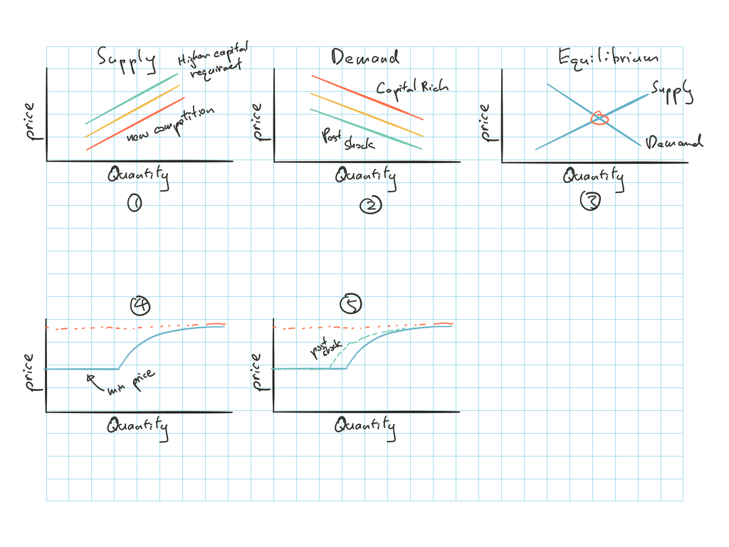

**Supply**

New competition or technology increases the quantity available at a given price  
$\hookrightarrow$ Shifting curve $\searrow$

Higher capital requirement  
$\hookrightarrow$ Shifting curve $\uparrow$

**Demand**

Excess capital makes insurance more valuable  
$\hookrightarrow$ Shifting curve $\nearrow$

Shock to capital  
$\hookrightarrow$ Shifting curve $\swarrow$

Company demand curve will be flatter since customers can go to another company for small changes in price

More intuitive to think of quantity as a function of price

Market price is where supply meets demand

Difficult to empirically estimate the curves because only the equilibrium is observable

**Gron Supply Curve**

Plot 4 and 5 above

The first flat section:

- There is a minimum price = expected losses + marginal expenses
- Supply is perfectly elastic for a certain quantity, where the supply will increase without an increasing price

The curved section:

- At certain point firm will require additional capital to support the business, and the price must increase
- Once price hits a a certain level, profits are enough to cover the additional capital and the supply curve approaches a price asymptotically

Shock scenario:

- Curve would simply shift $\leftarrow$
- Expected loss + marginal expense is still the same, while the amount of capital the company have before it needs to seek additional capital has changed

## Capital Flows

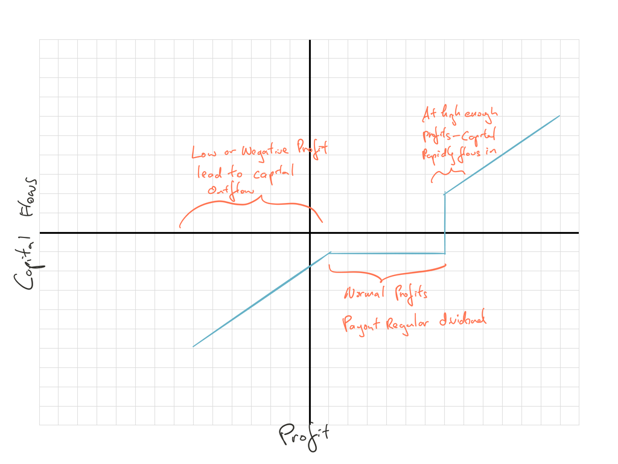

- Capital $\uparrow$ in a firm from retained earnings and capital infusions
- Capital $\downarrow$ from operating losses and capital withdrawal
- Capital is attracted when profit expectations are high
- Capital exits either voluntarily or under financial distress

## Assembling the Components

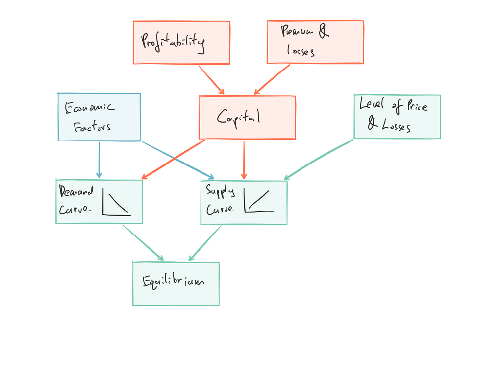

- Economic factors and capital both affect the supply and demand curves
- Level of price and losses affect the supply curve
- Capital is impacted directly by premium and losses and specifically profitability

Output of this model is an equilibrium price

The behavioral model can be used to simulate a dist<sup>n</sup> of this price

## Conclusion

U/w cycle is the behavior of a complex dynamic system

Output of the modeled u/w cycle should feed into the firm’s demand and retention models

- They help to forecast how clients will react to the difference between the firm’s pricing and that of other prices available in the market